# R Markdown Super Awesome Homework 1

Izzy Gaw

2020-01-16

On this page, you will find my code and visual representations of the Iris Dataset.

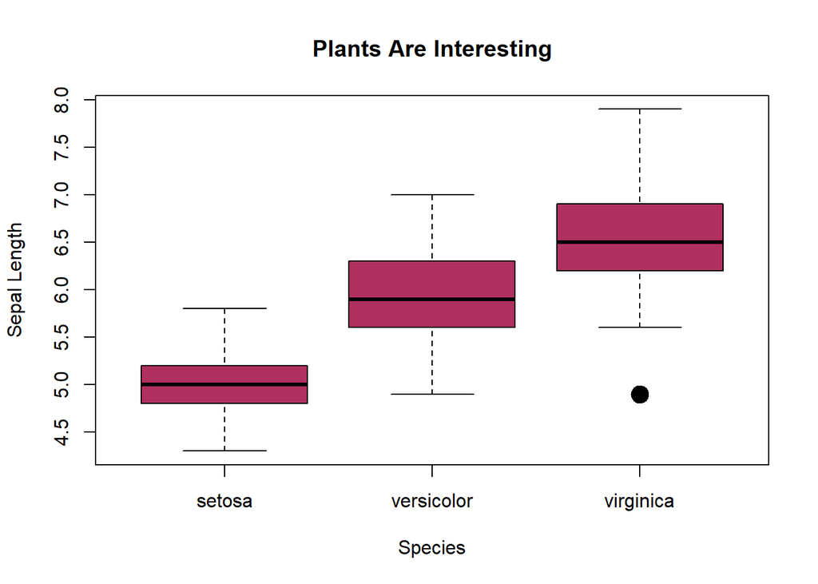

```r
plot(iris$Species, iris$Sepal.Length, main="Plants Are Interesting", ylab= "Sepal Length", xlab= "Species",cex=2, pch=19, col="maroon")
```

Figure 1. This boxplot shows the relationship between the three species sampled (Iris setosa, Iris virginica, and Iris versicolor) and their sepal length. Morphological differences between species in the same genus are incredibly interesting to study and vital to better understand because of their evolutionary significance.

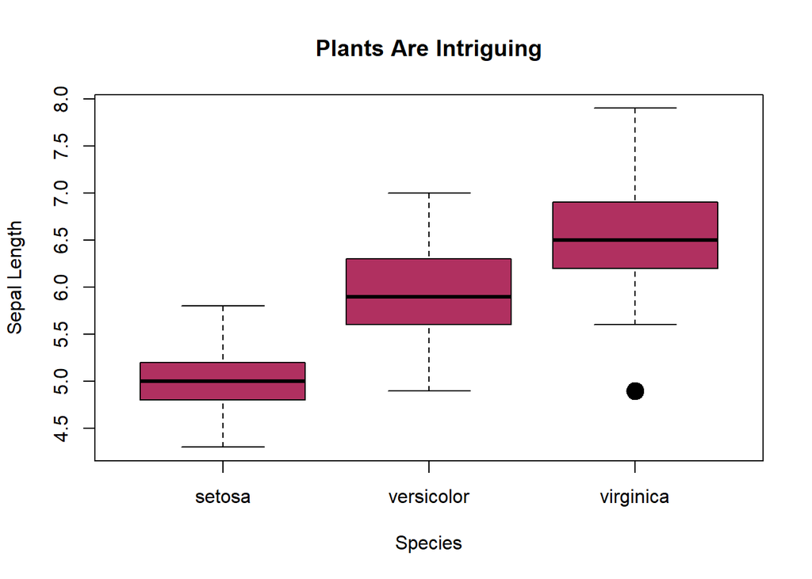

```r
plot(Sp, SepL, main="Plants Are Intriguing", ylab= "Sepal Length", xlab= "Species",cex=2, pch=19, col="maroon")
```

Figure 2. This boxplot is visually the same as the plot above, however, the code is different. Here I take what I implimented in the first plot but attempted to make the code more concise. It worked!

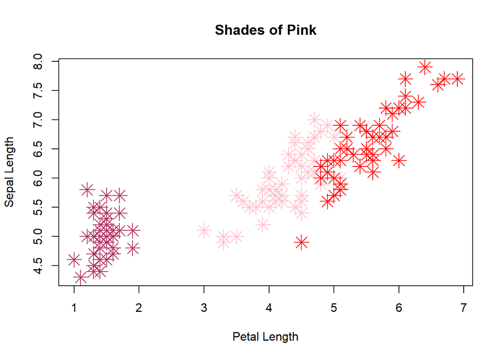

```r
plot(iris$Petal.Length, SepL, main="Shades of Pink", ylab="Sepal Length", xlab="Petal Length", col=color, cex=2, pch=8)
```

Figure 3. This scatterplot illustrates the relationship between petal length and sepal length of Iris setosa, Iris virginica, and Iris versicolor. Here, I tried to push myself and create a funky plot that not only created a gradient of color, but also created a scatterplot that showed the relationship between two morphological differences across all the three species. I thought this concept would be interesting to visually represent and challenging.